Analysis of TimeSeriesDataforStats072321.csv from 7/23/2021 email from Kayley Janssen

> One figure I am hoping to include is a time series of filtering to show decay rate or when/if a significant drop off in signal of SARS-CoV-2 and control viruses in wastewater held at 4 degrees occurs. We were provided with enough influent from 3 different wastewater treatment plants where we filtered duplicates of the sample almost every day over a 2 week period and then ran triplicates(technical replicates) of each filter on qPCR for N1, N2, BCoV, and PMMoV.

Fitting a linear model to log(concentration N1) seems appropriate: the slope of the regression line estimates the exponential rate of decay of concentration N1. Figure 1 shows the results of applying a mixed-effects model, estimating a common slope for the three WWTPs and letting concentration N1 vary between the three. The p-value for the slope coefficient is not significant.

To investigate why the data don’t fit this model, we fit linear models to each filter replicate independently. Figure 2 suggests that Wisconsin Rapids Filter replicate A might be an outlier. Excluding this sample from the dataset and fitting the mixed-effects model yields an estimated decay rate of -0.041 ± 0.016 GC/(L*day), ( p < 0.05), as shown in Figure 3.

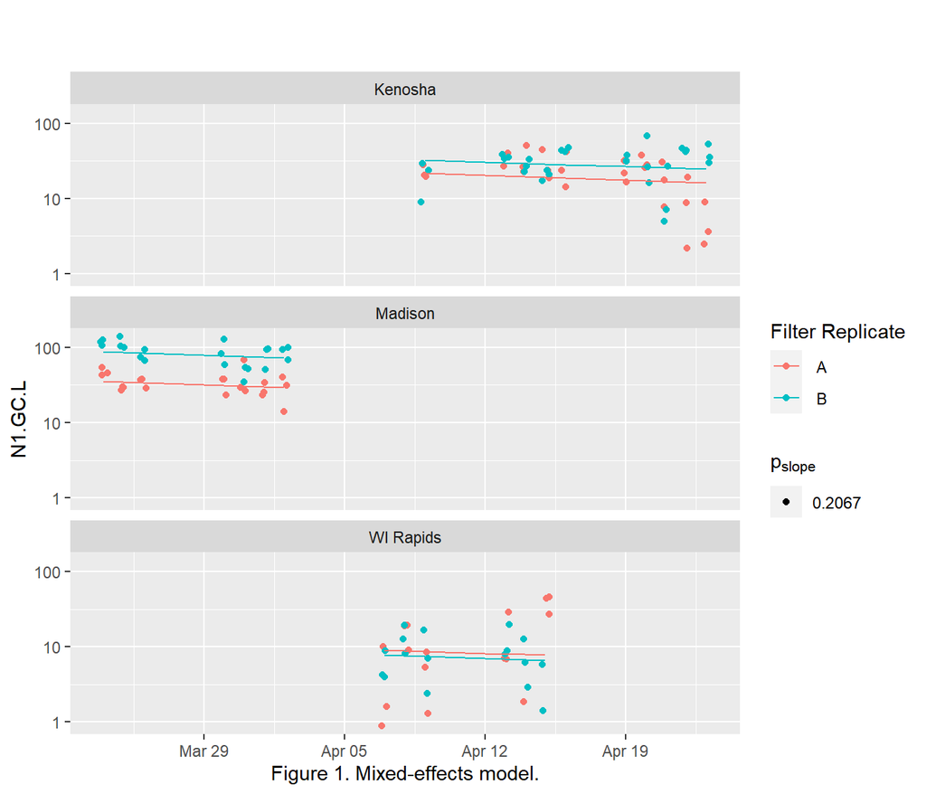

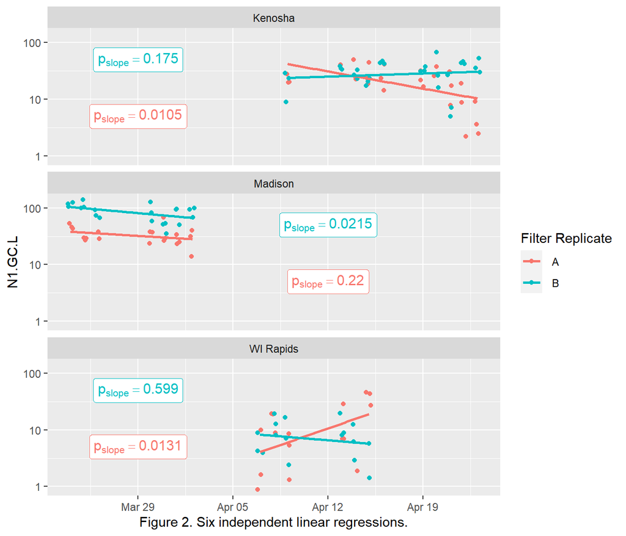

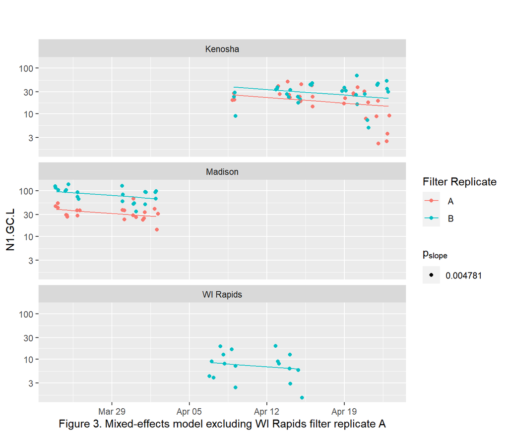

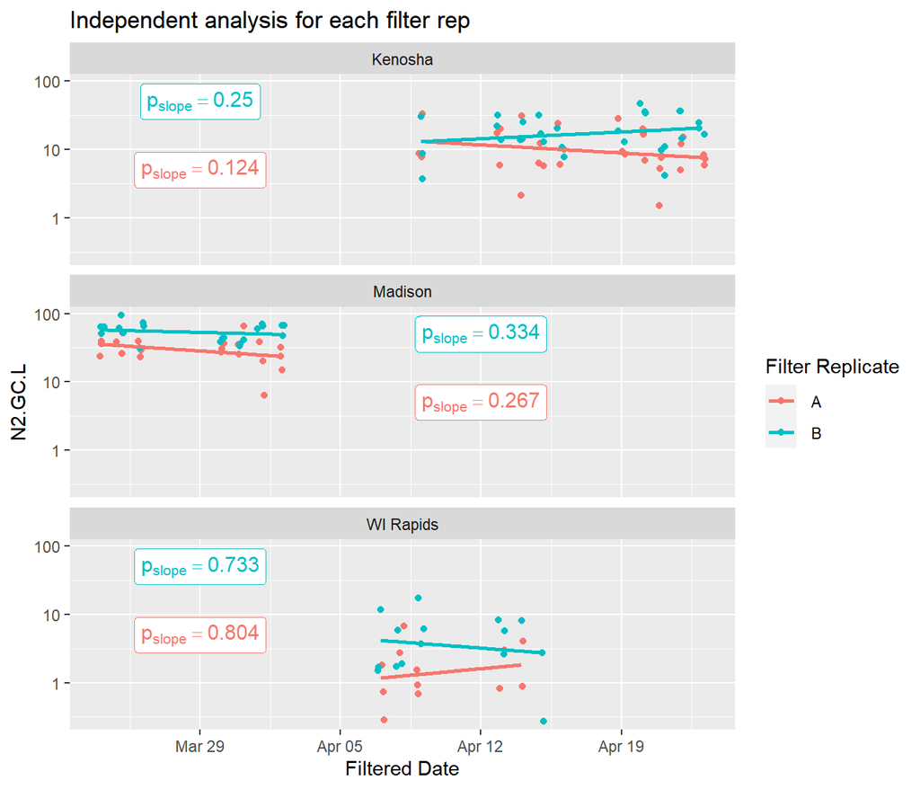

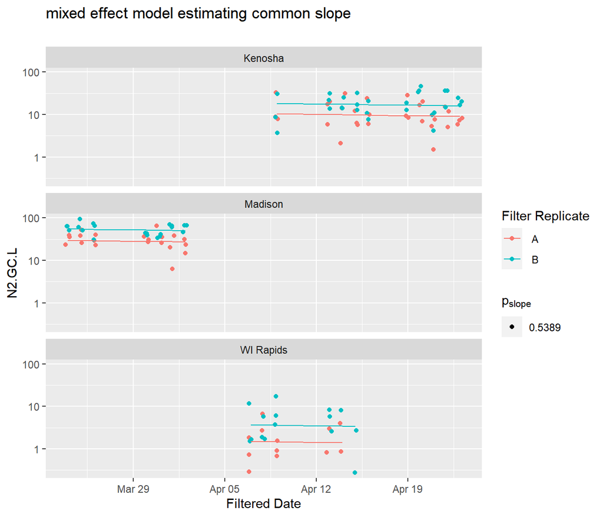

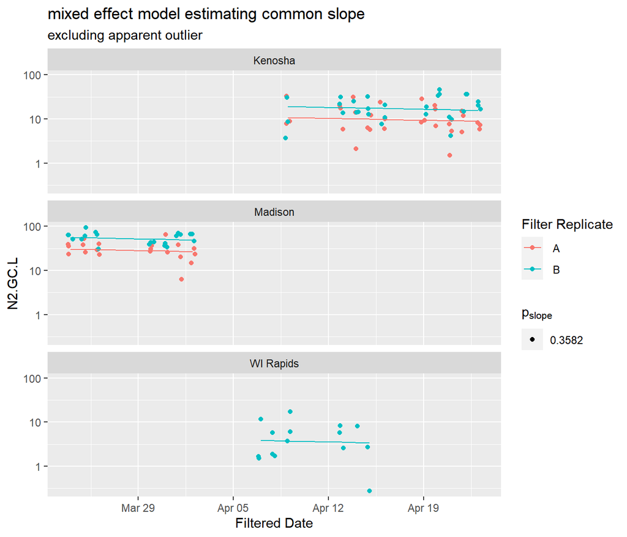

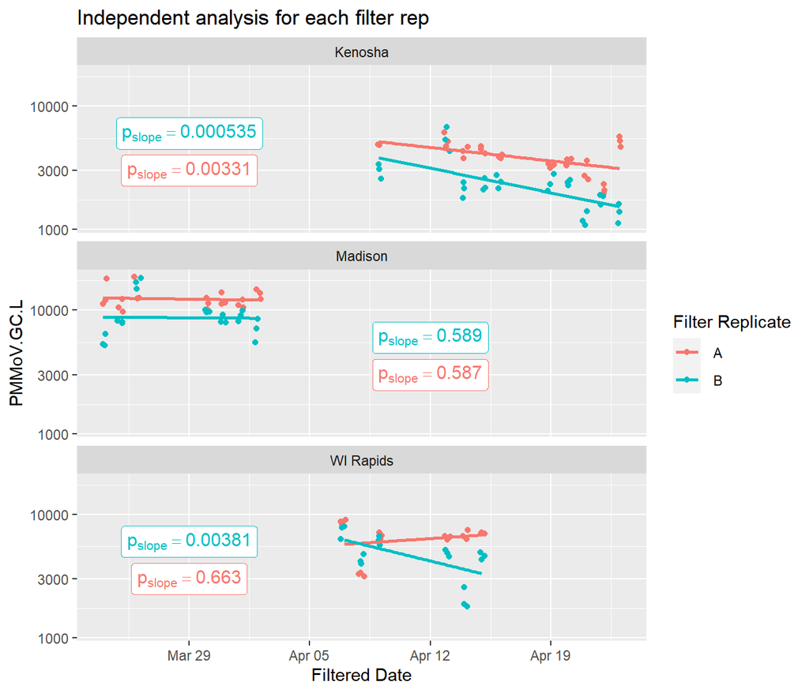

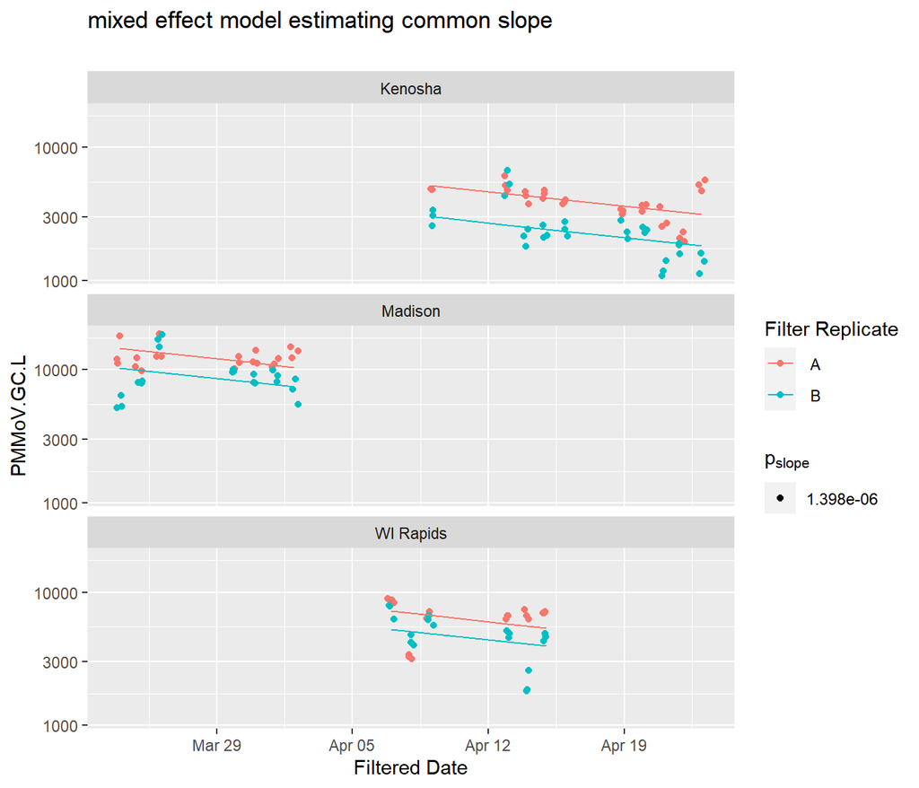

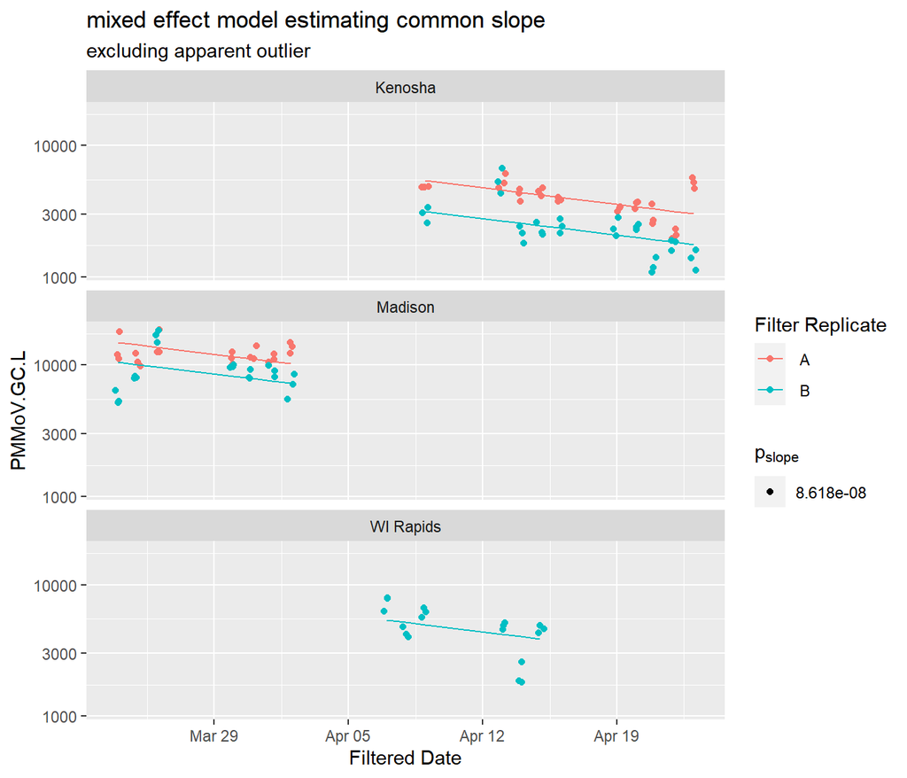

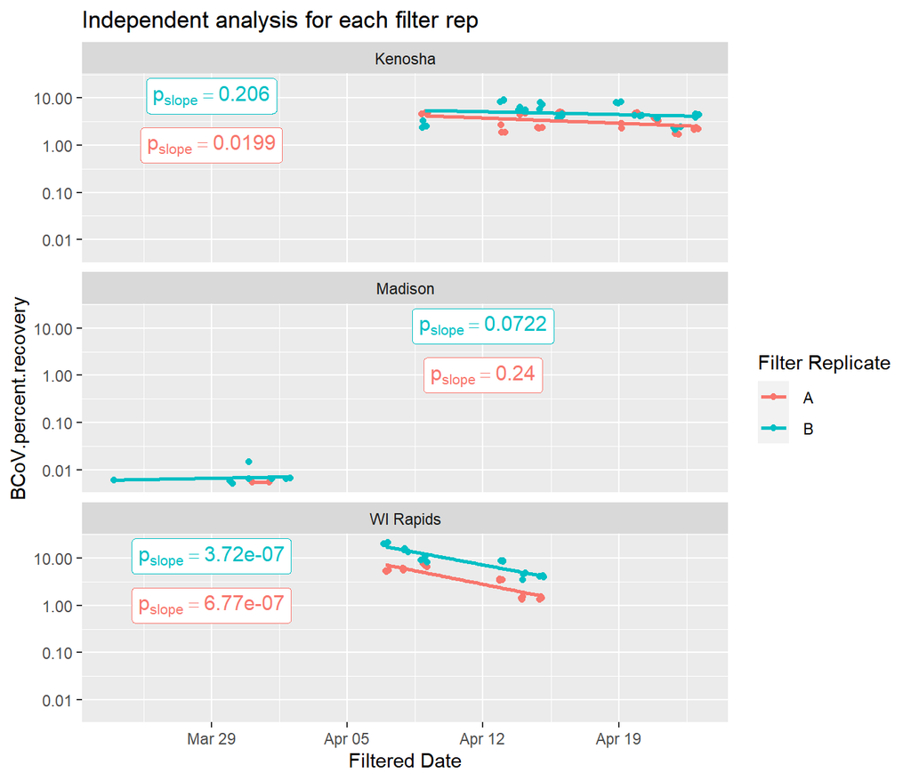

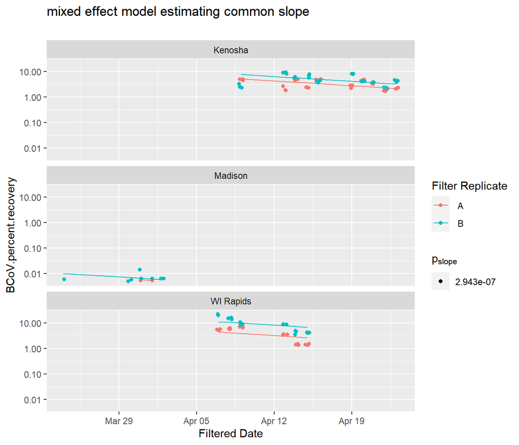

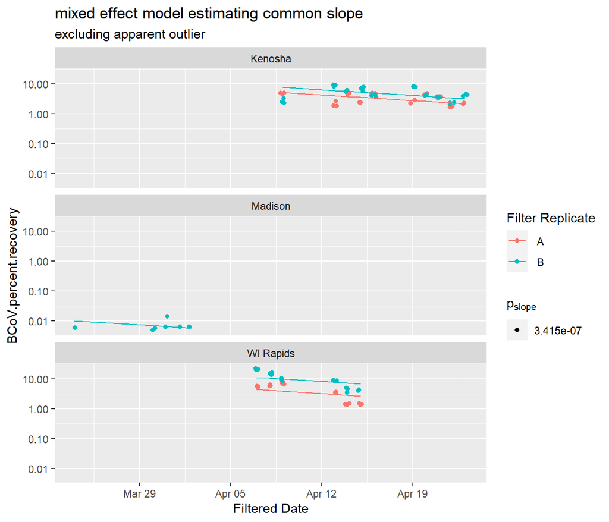